# 8k PBMC Example

## Section 6. Hierarchical visualization of markers

The cluster hierarchy has been integrated with the dotplot to show the marker expression architecture.

```r
## established markers
# get the markers
ct.markers = c("T-cell" = "CD3D","CD4" = "CD4","CD8" = "CD8A","CD8" = "NKG7",
               "effector CD8" = "IFNG",
               "Treg" = "FOXP3","Treg" = "IL2RA",
               "B-cell" = "CD19","Monocyte" = "CD14",
               "M1" = "HLA-DRA","M2" = "MSR1","MDSC" = "S100A9",
               "Dendritic" = "NRP1",
               "NK" = "NCAM1","Erythrocyte" = "HBA1","Platelet" = "PF4")
ct.markers.mapped = rownames(seu)[match(ct.markers,gsub("\\|(.*)$","",rownames(seu)))];
names(ct.markers.mapped) = names(ct.markers);

### get the plot
cnt = Seurat::GetAssayData(seu,assay = "RNA",slot = "counts")
mat = Seurat::GetAssayData(seu,assay = "RNA",slot = "scale.data")
rownames(cnt) = rownames(mat)
htbl = iter.res$module.table[,c("cluster.name","parent.cluster")];colnames(htbl) = c("module.id","module.parent")
modules = iter.res$modules
hplot.out = plot_hierarchy_dot.raw(m = mat,cnts = cnt,
                                   htbl,modules,celltype.markers = ct.markers.mapped,pct.mark = 0.1,
                                   plot.hierarchy = TRUE,
                                   filename = "pbmc_8k/hierarchy.celltype.png",width.per.plot = 500,height.per.plot = 3500)
```

```
## Calculate marker statistics...
## Plotting the hierarchy with dots...
## output plots to:pbmc_8k/hierarchy.celltype.png
```

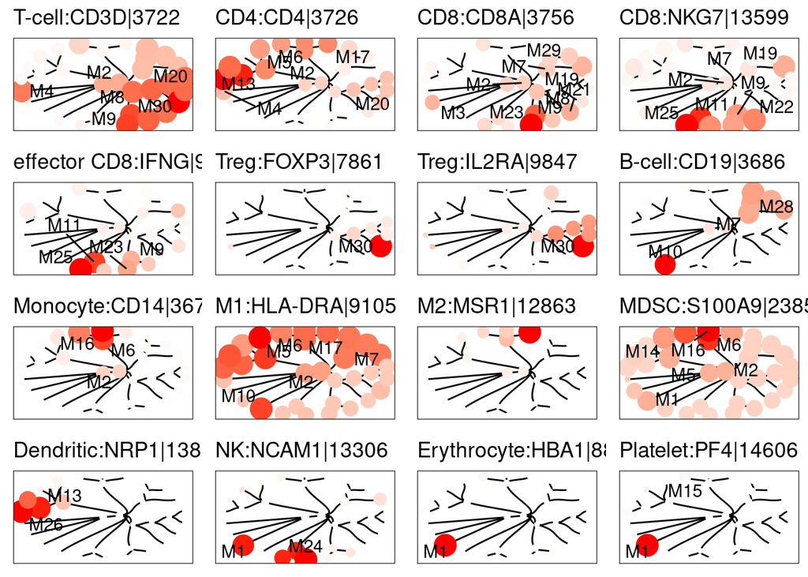

```r
plot_grid(plotlist = lapply(hplot.out$plotlist,function(x) x + theme(legend.position = "none")),ncol = 4)
```

## Section 7. Cell type annotations using SingleR

We used SingleR, as an independent cell type inference method. SingleR works with another R package, celldex, which holds comprehensive reference data sets for generic PBMC cell types.

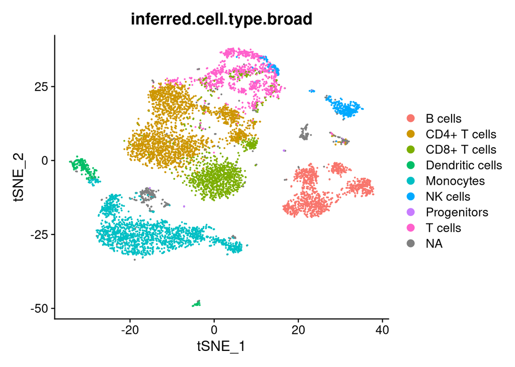

```r
library(SingleR)
library(celldex)
hpca.se <-  MonacoImmuneData()

m = GetAssayData(seu,assay = "RNA",slot = "scale.data")
rownames(m) = gsub("\\|(.*)$","",rownames(m))
gene.common = intersect(rownames(hpca.se),rownames(m))
hpca.se = hpca.se[gene.common,]
m = m[gene.common,]

# fine subtype
pred.ct <- SingleR(test = m, ref = hpca.se, assay.type.test=1,
                   labels = hpca.se$label.fine)

seu@meta.data$inferred.cell.type.fine = pred.ct$pruned.labels[match(colnames(seu),rownames(pred.ct))]

# fine subtype
pred.ct <- SingleR(test = m, ref = hpca.se, assay.type.test=1,
                   labels = hpca.se$label.main)

seu@meta.data$inferred.cell.type.broad = pred.ct$pruned.labels[match(colnames(seu),rownames(pred.ct))]

Seurat::DimPlot(seu,group.by = "inferred.cell.type.broad",reduction = "tSNE")
```

```r
rm(hpca.se)
gc()
```

```
##             used   (Mb) gc trigger   (Mb)   max used   (Mb)
## Ncells  10373765  554.1   16288224  869.9   16288224  869.9
## Vcells 794124906 6058.7 1277051528 9743.2 1063371649 8112.9
```

## Section 8. Visualize MSC results using various tools

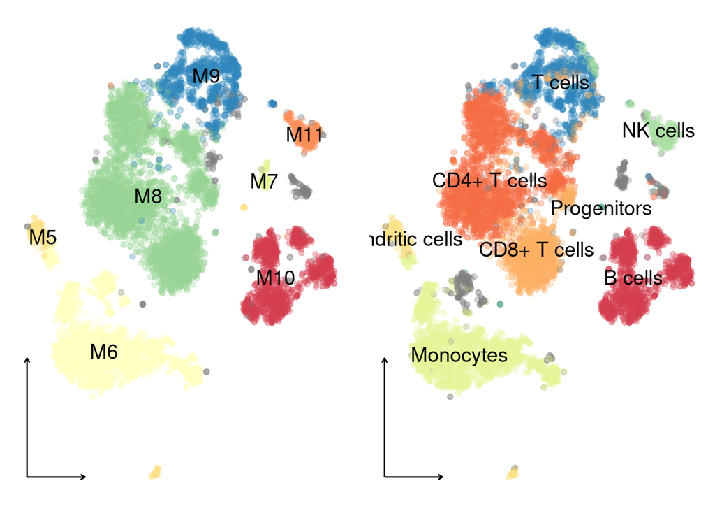

```r
### get embedding coordinates
xy = Embeddings(seu,"tSNE")
xy = xy[colnames(seu),]

### clustering results
# get the membership rooted to certain parent module
vec = get_rooted_membership(mtbl = iter.res$module.table,
                            modules = iter.res$modules,
                            pid = iter.res$root.cluster,bg = colnames(seu))
pobj.msc = plot_dimred_manual.raw(xy,
                                  cell.feat = vec,
                                  alpha.val = 0.3,cls.col = NULL,add.labels = TRUE)
# add other aesthetic features
pobj.msc = pobj.msc +
guides(colour = "none") +
  theme_classic() +
  theme(axis.line = element_blank(),axis.title = element_blank(),axis.text = element_blank(),axis.ticks = element_blank()) +
  annotate(geom = "segment",x = quantile(xy[,1],0),xend = quantile(xy[,1],0.1),y = min(xy[,2]),yend = min(xy[,2]),colour = "black",arrow = grid::arrow(length = unit(0.015, "npc"))) +
  annotate(geom = "segment",x = min(xy[,1]),xend = min(xy[,1]),y = min(xy[,2]),yend = quantile(xy[,2],0.1),colour = "black",arrow = grid::arrow(length = unit(0.015, "npc")) )

### get cell type tSNE plots
vec = seu@meta.data$inferred.cell.type.broad;names(vec) = colnames(seu)
pobj.ct.broad = plot_dimred_manual.raw(xy,cell.feat =vec,alpha.val = 0.3,cls.col = NULL,add.labels = TRUE) + guides(colour = "none") +
  theme_classic() +
  theme(axis.line = element_blank(),axis.title = element_blank(),axis.text = element_blank(),axis.ticks = element_blank()) +
  annotate(geom = "segment",x = quantile(xy[,1],0),xend = quantile(xy[,1],0.1),y = min(xy[,2]),yend = min(xy[,2]),colour = "black",arrow = grid::arrow(length = unit(0.015, "npc"))) +
  annotate(geom = "segment",x = min(xy[,1]),xend = min(xy[,1]),y = min(xy[,2]),yend = quantile(xy[,2],0.1),colour = "black",arrow = grid::arrow(length = unit(0.015, "npc")) )

library(cowplot)
print(plot_grid(pobj.msc,pobj.ct.broad,ncol = 2))
```

## Section 9. Hierarchical cluster respresentation with piecharts

The multi-scale clustering architecture in MSC can be effectively represented as a hierarchical dendrogram. Here, we make use of this hierarchy to visualize the cell cluster characteristic by pie charts at different hierarchical levels, allowing to inspect the relationship between the hierarchy and cell cluster features.

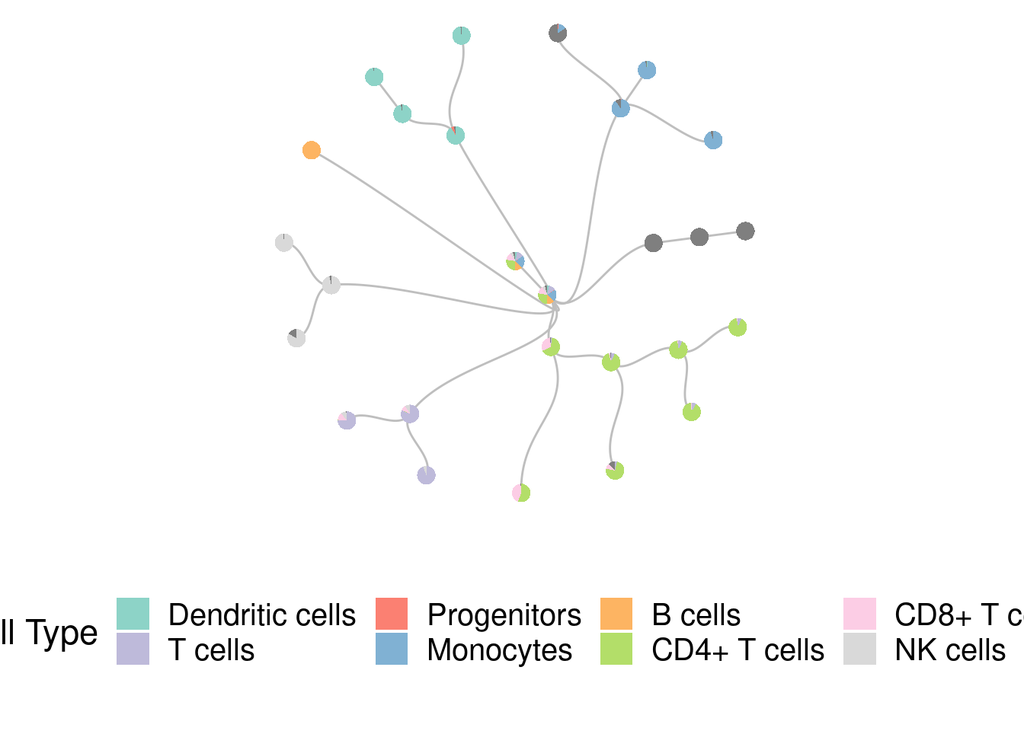

```r
library(RColorBrewer)

# assign cell type colors
vec.ct = seu@meta.data$inferred.cell.type.broad;names(vec.ct) = colnames(seu);
ct = unique(vec.ct)
colmap.ct = brewer.pal(n = length(ct),"Set3")
names(colmap.ct) = ct

# get cluster hierarchy
htbl = subset(iter.res$module.table,module.size >= 30)[,c("cluster.name","parent.cluster")]
modules = iter.res$modules

# make piechart
pie.ct = plot_hierarchy_pie(htbl,modules,vec.ct,colmap = colmap.ct,edge_colour = "grey")
pie.ct = pie.ct + guides(fill = guide_legend(label.theme = element_text(size = 15),title.theme = element_text(size = 17),title = "Cell Type"))

# extract legend
library(ggpubr)
leg = get_legend(pie.ct)
leg = as_ggplot(leg)

txt.dat = pie.ct$data[,c("x","y","name")]
txt.dat = subset(txt.dat,name %in% c(subset(iter.res$module.table,parent.cluster == "M1")$cluster.name))
library(ggrepel)
pie.ct = pie.ct + geom_text_repel(data = txt.dat,aes(x = x,y = y,label = name),colour = "darkblue",segment.colour = "darkblue",vjust = 1.5,size = 6) +
  guides(fill = "none") +
  theme(panel.border = element_blank(),legend.position = "right",legend.direction = "vertical",
        legend.text = element_text(size = 16),
        plot.title = element_text(size = 20,hjust = 0.5),
        plot.margin = margin(t = 0,r = 0,b = 0,l = 0))
pie.ct = plot_grid(pie.ct,leg,ncol = 1,rel_heights = c(0.8,0.3))

print(pie.ct)
```